# Authoring R Markdown documents with BiocStyle

European Bioconductor Developers’ Meeting 2016

## BiocStyle milestones

### Standard formatting style for Bioconductor documents

- LaTeX .sty file for PDF documents (v1.0)
- CSS definitions for markdown HTML documents (v1.4)
- *rmarkdown* templates for HTML/PDF vignettes (v1.8)
- New LaTeX style (v2.0)
- New HTML style supporting cross-references* (v2.2)

*a subset of functionality offered by R package *bookdown*

## User uptake

[figure not shown]

* software and experiment data packages

## Vignette stats

[figure not shown]

* software packages

## Problems with the original style

### Inconsistent formatting

- within document (title page vs. document body)
- across output formats (PDF vs. HTML)

### Non-distinctive structuring elements

- running head, folio (PDF)
- figure captions

### Format-varying appearance of code chunks

- code highlighting
- background

### No support for the recent *rmarkdown* features (HTML)

- floating TOC, code folding, …

## BiocStyle 2.0

### Design goals

- Easy to read and visually attractive
- Clear separation between content and structuring elements
- Common style regardless of input (Rnw/Rmd) and output format (PDF/HTML)

### Implementation

- Consistent layout emphasizing relationships
  - horizontal content alignment
  - distinct fonts for structuring elements and main text
- Common themes for code highlighting
- Footnotes as margin notes

## Enabling BiocStyle in Rmd package vignette

- Add to **DESCRIPTION**

  ```
  VignetteBuilder: knitr
  Suggests: BiocStyle, knitr, rmarkdown
  ```

- Specify BiocStyle output format and vignette metadata in **document header**

  ```
  ---
  title: "Vignette Title"
  author: "Vignette Author"
  package: PackageName
  output:
    BiocStyle::html_document2
  vignette: >
    %\VignetteIndexEntry{Vignette Title}
    %\VignetteEngine{knitr::rmarkdown}
    %\VignetteEncoding{UTF-8}
  ---
  ```

## Author affiliations

YAML header demonstrating anchor-reference notation

```
author:
- name: First Author
  affiliation:
  - &id Shared affiliation
  - Additional affiliation
- name: Second Author
  affiliation: *id
- name: Last Author
  affiliation: *id
  email: corresponding@author.com
```

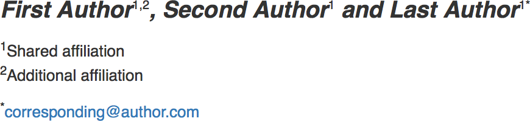

## Cross-references and package links

### Functionality provided by *bookdown*

- automatic numbering of figures, tables and equations
- output-independent syntax for specifying cross-references
  - label `(\#label)`
  - reference `\@ref(label)`

### Macros for linking to *R* packages

- `Biocpkg("IRanges")` : *IRanges*
- `CRANpkg("data.table")` : *[data.table](http://cran.fhcrc.org/web/packages/data.table/index.html)*
- `Githubpkg("rstudio/rmarkdown")` : *rmarkdown*

Called inline: `` `r Biocpkg("IRanges")` ``

## Figures

### Three figure sizes with predefined aspect ratio

- specified through `fig.small` and `fig.wide`

### Caption titles

- emphasized first sentence of captions

### Numbering and referencing

- specify `fig.cap` and use `\@ref(fig:label)`

## Tables

Assign labels `(\#tab:label)` in captions and refer to them by `\@ref(tab:label)`

```
Fruit   | Price
------- | -----
bananas | 1.2
apples  | 1.0
oranges | 2.5

: (\#tab:table) A simple table. With caption.
```

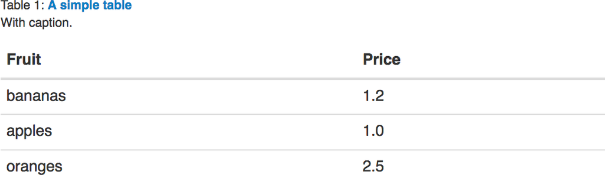

## Equations

To number and reference equations put them in equation environments and assign labels `(\#eq:label)` to them

```latex
\begin{equation}
  f\left(k\right) = \binom{n}{k} p^k\left(1-p\right)^{n-k}
  (\#eq:binom)
\end{equation}
```

\[ \qquad\qquad\qquad\qquad f\left(k\right) = \binom{n}{k} p^k\left(1-p\right)^{n-k} \qquad\qquad\qquad\quad(1) \]  
Use `\@ref(eq:binom)` to refer to Equation (1)

## Acknowledgments

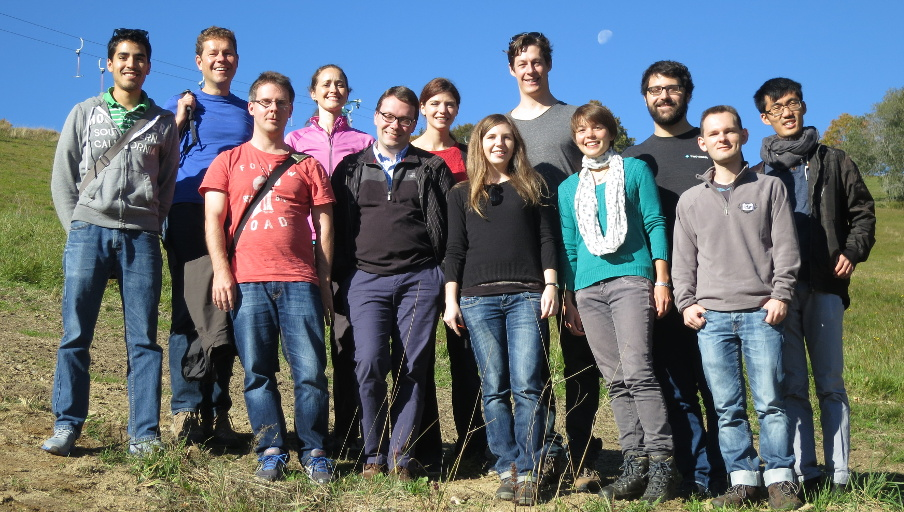

Huber Group @

[figure not shown]

Heidelberg

*graphic design*: Lorraine Garchery

*feedback*: Laurent Gatto, Leonardo Collado-Torres, Ramon Diaz-Uriarte